# Analysing interventions in time with the Changepoint package

16 September 2017

## This session

- Context
- What is changepoint analysis
- Why use it
- When to use it
- Case Study: Sexual offences on public transport

## The context

Understanding the impact of policing interventions is essential to building an evidence base.

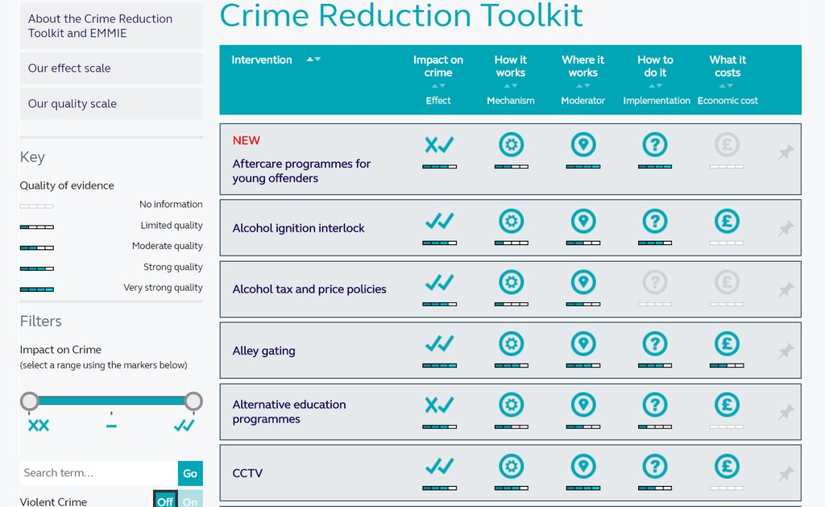

## Crime trends

Time series are often used in enforcement to:

- Monitor crime trends
- Understand seasonal patterns
- Check whether an intervention has worked

Data can be noisy, and the volume of offences often fluctuate, it can be hard to tell whether a genuine change occured and at what point.

## Detecting changes

Ideally we want something that does this

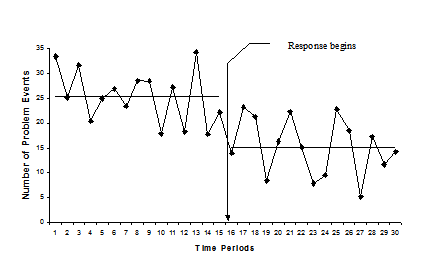

**Source**: www.popcentre.org

## Changepoint package

Authored by:

- Rebecca Killick (Lancaster University)
- Kaylea Haynes
- Idris Eckley
- Paul Fearnhead
- Jamie Lee

**The main paper**: Killick, Rebecca and Eckley, Idris (2014) changepoint : an R package for changepoint analysis. Journal of Statistical Software, 58 (3). pp. 1-19.

The package provides a range of methods for detecting changes in time series data. We can install and load into R as follows:

install.packages("changepoint")

library(changepoint)

## Testing an intervention example

**Scenario**

A new police operation was launched to combat the high level of violent offences in Townsville. We want to know if violence reduced following the start of the intervention.

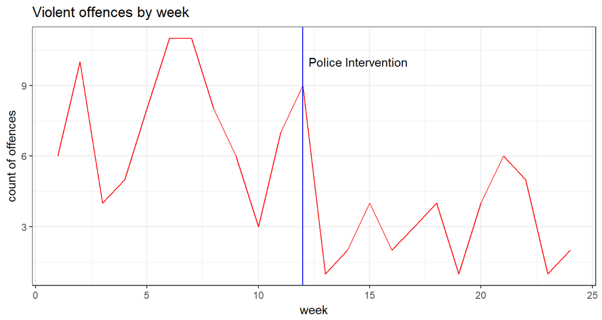

## Using Changepoints - AMOC

Changepoint has a very straight forward function for analysing whether a change in the mean or average number of crime has occured: cpt.mean().

We simply feed our data into the function and by default it will look to see whether At Most Once Change (AMOC) happened.

That's useful if we want to test whether our intervention has had an impact and we can plot the result too.

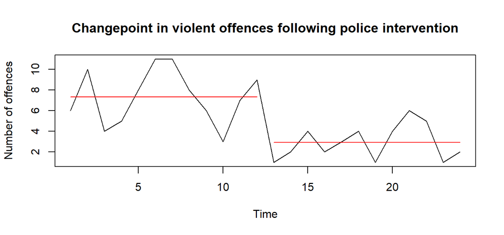